# 第7回 確率を出し、誤りの重さでしきい値を決める

# 5. どこで切るか？

## 残るはしきい値

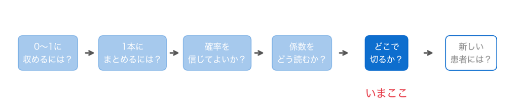

- 確率が出せて、その読み方も分かった
- 残るのは、どの確率から造影を勧めるか

## お手本：0.5で切ると

5節 ① 0.5で切ると●○

```python
print(confusion_matrix(y_true, (p_te >= 0.5).astype(int)))
```

```
[[29  3]
 [ 6 22]]
```

- 見逃し6人、誤検出3人。外れた人は9人

## 2つの外れは重さが違う

5節 ① 0.5で切ると●●

- 見逃すと、心臓病の人が治療の機会を失う
- 誤検出なら、健康な人が、負担のある造影を受ける

## やってみよう：問いを書く

5節 ② 重さを置く●○○○

- 医師として、見逃し1人の重さは、誤検出何人分だと考えるか
- ノートの「問い」の欄に、考えを書く

動画の人は、ここで一時停止。

## 重さは、データからは決まらない

5節 ② 重さを置く●●○○

- 病気の重さ、検査の負担、患者の考えから、医師と患者が決める
- 解析する人が決めた重さは、報告に書き残す

## 今日は5人分と置く

5節 ② 重さを置く●●●○

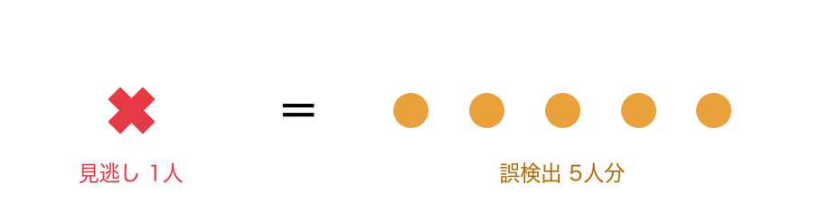

- 見逃し1人を、誤検出5人分の重さと置く

## 名前：損失

5節 ② 重さを置く●●●●

$$\text{損失} = c_{FP} \times \text{FP} + c_{FN} \times \text{FN}$$

- 外れ方を、1つの数にする。損失（loss）と呼ぶ
- 今日は$c_{FP} = 1$、$c_{FN} = 5$。損失がいちばん小さいしきい値を選ぶ

## しきい値も「選ぶ」もの

5節 ③ 損失の表●○○○○

- しきい値も、第5回の`alpha`と同じく、データを見て選ぶ
- テストで選ぶと、テストが最後の確かめにならない
- 3節の`p_cv`（訓練の人の、式が見ていない確率）で選ぶ

## お手本：しきい値ごとの損失

5節 ③ 損失の表●●○○○

```python
c_fp, c_fn = 1, 5                       # 見逃しは誤検出の5倍
y_cv = y_tr.values
rows = []
for t in np.arange(0.1, 1.0, 0.1):
    t = round(t, 1)
    p = (p_cv >= t).astype(int)
    fp = ((p == 1) & (y_cv == 0)).sum()
    fn = ((p == 0) & (y_cv == 1)).sum()
    rows.append({'しきい値': t, '誤検出': fp, '見逃し': fn,
                 '損失': c_fp * fp + c_fn * fn})
cost = pd.DataFrame(rows)
print(cost)
```

## 前回の表と同じ形

5節 ③ 損失の表●●●○○

- 前回の6節の、しきい値ごとの表と同じ形
- 違うのは、数える確率が`p_cv`で、損失の列を足したこと

## しきい値ごとの損失

5節 ③ 損失の表●●●●○

```
   しきい値  誤検出  見逃し   損失
0   0.1   69    4   89
1   0.2   41   10   91
2   0.3   30   14  100
3   0.4   27   18  117
4   0.5   22   21  127
5   0.6   12   29  157
6   0.7    9   40  209
7   0.8    8   47  243
8   0.9    4   55  279
```

## 0.1と0.2がほぼ同じ

5節 ③ 損失の表●●●●●

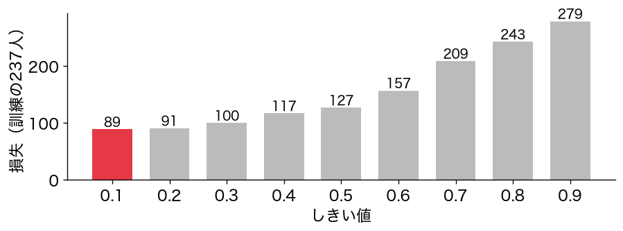

- いちばん小さいのは0.1で89。0.2でも91。0.5では127
- 見逃しを5倍重く見ると、0.5よりずっと低いしきい値がよい

## 式で考える：確率pの患者

5節 ④ 式で考える●○○○○○

- 心臓病である確率が$p$の患者を1人考える
- 「心臓病」と判定すると、外れるのは心臓病でなかったとき（確率$1 - p$）
- 「心臓病でない」と判定すると、外れるのは心臓病だったとき（確率$p$）

## 損失の見込み

5節 ④ 式で考える●●○○○○

$$\text{「心臓病」：}(1 - p)\,c_{FP} \qquad \text{「でない」：}p\,c_{FN}$$

- 外れる確率に、外れたときの重さをかける
- 損失の見込みが小さいほうの判定を選ぶ

## たとえばp＝0.3なら

5節 ④ 式で考える●●●○○○

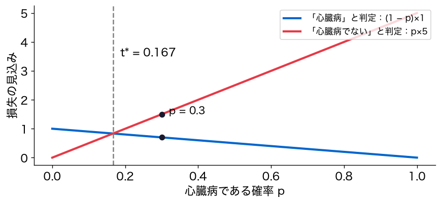

- 「心臓病」なら0.7×1、「でない」なら0.3×5。造影を勧めるほうが小さい

## 2本の線が交わる点

5節 ④ 式で考える●●●●○○

$$(1 - p)\,c_{FP} < p\,c_{FN}
\quad \Longleftrightarrow \quad
p > \frac{c_{FP}}{c_{FP} + c_{FN}}$$

- 右辺が、選ぶべきしきい値$t^*$
- 確率が信じられる（較正がとれている）ことが前提

## お手本：しきい値を計算する

5節 ④ 式で考える●●●●●○

```python
t_star = c_fp / (c_fp + c_fn)
print(round(t_star, 3))
```

```
0.167
```

- $t^* = 1/6$で0.167。表の0.1と0.2の間にある

## 交わるのは1/6

5節 ④ 式で考える●●●●●●

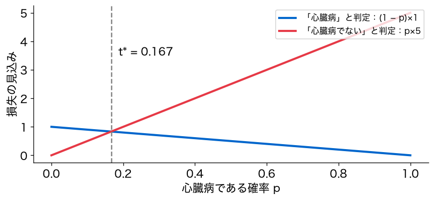

- それより右では、造影を勧めるほうが損失の見込みが小さい

## 変えてみる：0.01刻みで

5節 ⑤ 細かく確かめる●○○○

```python
ts = np.arange(1, 100) / 100            # 0.01, 0.02, ..., 0.99
losses = []
for t in ts:
    p = (p_cv >= t).astype(int)
    fp = ((p == 1) & (y_cv == 0)).sum()
    fn = ((p == 0) & (y_cv == 1)).sum()
    losses.append(c_fp * fp + c_fn * fn)
plt.plot(ts, losses)
plt.axvline(t_star, color='gray', ls='--')
plt.xlabel('しきい値')
plt.ylabel('損失（訓練の237人）')
plt.show()
print(ts[np.argmin(losses)], min(losses))
```

## np.argminは位置を返す

5節 ⑤ 細かく確かめる●●○○

- `np.argmin`は、並びの中でいちばん小さい値の位置（何番目か）を返す
- `ts[np.argmin(losses)]`で、損失がいちばん小さいしきい値になる

## 0.16で最小

5節 ⑤ 細かく確かめる●●●○

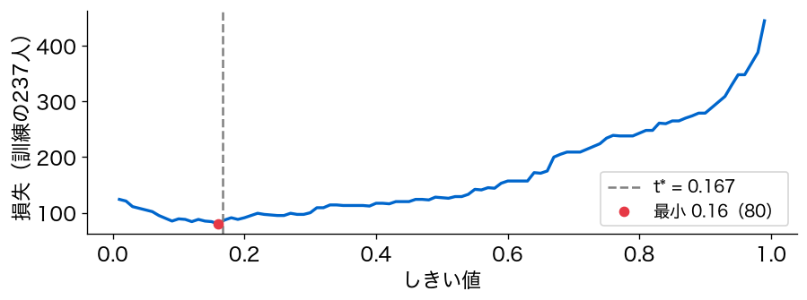

```
0.16 80
```

- 損失は0.16で最小（80）。式の$t^* = 0.167$とほぼ同じ場所

## データでも式でも同じ

5節 ⑤ 細かく確かめる●●●●

- データで探しても、式で出しても、同じしきい値にたどり着く
- 式なら、重さが変わってもすぐに出し直せる

## TODO④：重さを変えると

5節 ⑥ 重さを変える●○○○○

```python
# TODO: c_fn3 = 3 のときの t* と、しきい値ごとの損失の表を出す
# ヒント: t3 = c_fp / (c_fp + c_fn3)
#         表は、お手本のセルの c_fn を c_fn3 に変える
...
```

- 見逃しの重さを、誤検出の3倍にする
- あとのセルを変えないように、新しい名前`c_fn3`・`t3`を使う

## やってみよう：5節とTODO④

5節 ⑥ 重さを変える●●○○○

- 5節のお手本と「変えてみる」のセルを実行する
- TODO④で、重さを3倍にしたときの$t^*$と表を出す

動画の人は、ここで一時停止。

## 答え合わせ：TODO④

5節 ⑥ 重さを変える●●●○○

```python
c_fn3 = 3
t3 = c_fp / (c_fp + c_fn3)
print(t3)
rows = []
for t in np.arange(0.1, 1.0, 0.1):
    t = round(t, 1)
    p = (p_cv >= t).astype(int)
    fp = ((p == 1) & (y_cv == 0)).sum()
    fn = ((p == 0) & (y_cv == 1)).sum()
    rows.append({'しきい値': t, '誤検出': fp, '見逃し': fn,
                 '損失': c_fp * fp + c_fn3 * fn})
print(pd.DataFrame(rows))
```

## 重さ3倍なら0.25

5節 ⑥ 重さを変える●●●●○

```
0.25
   しきい値  誤検出  見逃し   損失
0   0.1   69    4   81
1   0.2   41   10   71
2   0.3   30   14   72
3   0.4   27   18   81
4   0.5   22   21   85
5   0.6   12   29   99
6   0.7    9   40  129
7   0.8    8   47  149
8   0.9    4   55  169
```

- 表では0.2が71でいちばん小さく、0.3が72で続く

## 重さで、しきい値が動く

5節 ⑥ 重さを変える●●●●●

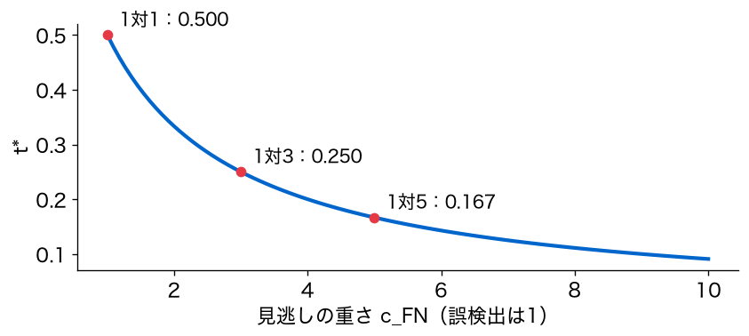

- 見逃しの重さが軽くなるほど、0.5に近づく。1対1なら$t^* = 0.5$

## お手本：テストで確かめる

5節 ⑦ テストで確かめる●○○○

```python
for t in [0.5, t_star]:
    p = (p_te >= t).astype(int)
    fp = ((p == 1) & (y_true == 0)).sum()
    fn = ((p == 0) & (y_true == 1)).sum()
    print(round(t, 3), '誤検出', fp, '見逃し', fn,
          '損失', c_fp * fp + c_fn * fn)
```

- しきい値は訓練で選んだ。最後に、テストの60人で比べる

## 損失は33から19に

5節 ⑦ テストで確かめる●●○○

```
0.5 誤検出 3 見逃し 6 損失 33
0.167 誤検出 14 見逃し 1 損失 19
```

- 0.5：誤検出3人・見逃し6人。$t^*$：誤検出14人・見逃し1人

## 見逃しと誤検出の入れ替え

5節 ⑦ テストで確かめる●●●○

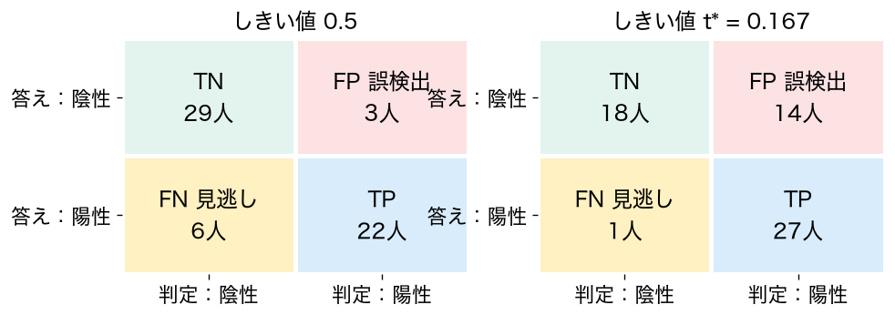

- 心臓病の28人のうち27人を造影に回せる
- そのかわり、でない人のうち14人にも造影を勧める

## この入れ替えが得

5節 ⑦ テストで確かめる●●●●

- 見逃しを5倍重く見るなら、この入れ替えが得になる
- 重さが違えば、得な入れ替えも変わる

# 6. 新しい患者には？

## 確率と判定を伝える

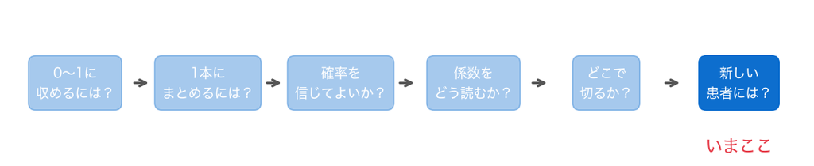

- しきい値が決まった。新しく来た患者に、確率と判定を伝える
- テストの1人目を、今日外来に来た患者とする。式はまだ見ていない

## お手本：1人の確率

6節 ① 1人の確率●○

```python
new = X_te.iloc[[0]]                    # テストの1人目
print(new[['年齢', '最大心拍数', 'ST低下', '血管の数']])
p_new = pipe.predict_proba(new)[0, 1]
print(round(p_new, 3))
```

- 角かっこを2重にすると、1行だけの表として取り出せる

## 確率は0.307

6節 ① 1人の確率●●

```
      年齢  最大心拍数  ST低下  血管の数
69  46.0  147.0   3.6   0.0
0.307
```

- 46歳で、ST低下が3.6と大きい人
- 標準化は、パイプラインが訓練の平均と標準偏差で済ませる

## お手本：文にする

6節 ② 文にする●○○○

```python
if p_new >= t_star:
    msg = '造影を勧めます'
else:
    msg = '造影は勧めません'
print(f'心臓病である確率は{p_new:.1%}です。')
print(f'しきい値{t_star:.1%}と比べて、{msg}。')
```

- `if`と`else`で、条件が成り立つかどうかで、入れる言葉を変える
- `{p_new:.1%}`は、百分率で小数第1位まで（前回のおさらい）

## 患者に伝える文

6節 ② 文にする●●○○

```
心臓病である確率は30.7%です。
しきい値16.7%と比べて、造影を勧めます。
```

## 0.5なら見逃していた

6節 ② 文にする●●●○

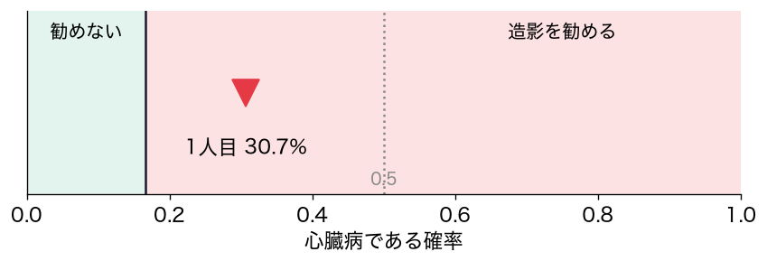

- 0.5で切っていたら、「心臓病でない」と判定された人
- 前回の線形回帰でも、式の値0.33で見逃されていた

## 実際の答えは

6節 ② 文にする●●●●

```python
print(y_true[0])
```

```
1
```

- 答えは1。この人は心臓病だった。重さから決めたしきい値で、見逃さずに済んだ

## TODO⑤：別の患者

6節 ③ 別の患者●○○○

```python
# TODO: テストの16人目の確率を出し、判定の文を表示する
# ヒント: new2 = X_te.iloc[[15]]
#         p2 = pipe.predict_proba(new2)[0, 1] として、お手本をまねる
...
```

- テストの16人目を、新しく来た患者とする

## やってみよう：6節とTODO⑤

6節 ③ 別の患者●●○○

- 6節のお手本を実行し、1人目の確率と文を確かめる
- TODO⑤で、16人目の確率と判定の文を出す

動画の人は、ここで一時停止。

## 答え合わせ：TODO⑤

6節 ③ 別の患者●●●○

```python
new2 = X_te.iloc[[15]]
p2 = pipe.predict_proba(new2)[0, 1]
if p2 >= t_star:
    msg = '造影を勧めます'
else:
    msg = '造影は勧めません'
print(f'心臓病である確率は{p2:.1%}です。')
print(f'しきい値{t_star:.1%}と比べて、{msg}。')
print(y_true[15])
```

## 16人目は勧めない

6節 ③ 別の患者●●●●

```
心臓病である確率は0.5%です。
しきい値16.7%と比べて、造影は勧めません。
0
```

- 確率0.5%で、造影は勧めない。答えは0で、心臓病ではなかった

## 答え：確率は1本で出す

6節 ④ 答え●○○

標準化とロジスティック回帰を1本にしたパイプラインで、心臓病である確率を出せる。確率は0〜1に収まり、幅ごとの実際の割合とも、おおむね合う（0.8より大きい70人で、確率の平均0.95・実際0.886）。

## 答え：しきい値は1/6

6節 ④ 答え●●○

見逃し1人を誤検出5人分と重く見るなら、しきい値は$t^* = 1/6$（0.167）。テストでは、見逃し6人・誤検出3人（0.5）が、見逃し1人・誤検出14人になり、損失は33から19に下がる。

## 答え：今日の患者

6節 ④ 答え●●●

- 1人目の患者は、確率30.7%
- しきい値16.7%を超えるので、造影を勧める

## まだ言えないこと①：重さ

6節 ⑤ まだ言えないこと●○○

- 5倍は、仮に置いた値。データからは決まらない
- 病気の重さや患者の考えで変わり、変われば$t^*$も変わる

## まだ言えないこと②：ほかの場

6節 ⑤ まだ言えないこと●●○

- 確率の較正は、この外来の患者で確かめたもの
- 有病率の違う場では、確率そのものがずれる

## まだ言えないこと③：区分の列

6節 ⑤ まだ言えないこと●●●

- `get_dummies`は、渡した表にある区分だけを列にする
- 新しい患者1人の表に使うと、列がそろわない
- 今日は、テストの行（すでにそろった列）を使った

# まとめ

## 今日の道筋を振り返る

⑥ 振り返る●○○○○○

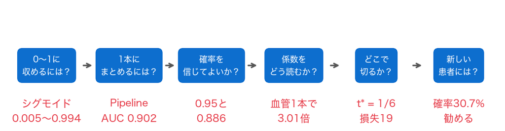

- 6つの小さな問いに答えて、確率としきい値を決められるようになった

## 今日の歩み

⑥ 振り返る●●○○○○

シグモイド → 標準化 → クラス → パイプライン → 較正 → オッズ比 → 損失としきい値

## 今日持ち帰る1文

⑥ 振り返る●●●○○○

確率は、訓練で決めた標準化とモデルを1本のパイプラインにして出す。しきい値は、見逃しと誤検出の重さから決める（見逃しが誤検出の5倍重いなら1/6）。

## 今日の要点①：確率

⑥ 振り返る●●●●○○

- ロジスティック回帰は、線形の式をシグモイド関数に通して0〜1の確率にする
- `ConvergenceWarning`は読み飛ばさない。尺度の違う列は標準化してから
- 確率の幅ごとに実際の割合を比べ、較正を確かめる

## 今日の要点②：部品

⑥ 振り返る●●●●●○

- クラスは値と手順のまとまり。`fit`で`self`に覚え、`transform`や`predict`で使う
- `make_pipeline`で部品をつなぐと、標準化を忘れず、交差検証の各回の中でも訓練だけで標準化できる

## 今日の要点③：読む・決める

⑥ 振り返る●●●●●●

- $e^{\text{係数}}$は、オッズ比（1増えると、オッズが何倍か）
- 損失＝$c_{FP}$×誤検出＋$c_{FN}$×見逃し
- しきい値は$t^* = c_{FP}/(c_{FP} + c_{FN})$

## 課題の出し方

⑦ このあと●○○○

- ノートの最後の「課題（提出）」に取り組む
- 応用②の答えと応用③の文章を、LACSに入力して提出（＝出席。期限なし）
- AIを使ってもよい。何を聞いて、どう直したかを1行書く

## 次回予告：一周する

⑦ このあと●●○○

- データを読み込み、前処理をして、式を作り、評価し、解釈する
- その一連の道具が、今日までにそろった

## 次回の問い

⑦ このあと●●●○

新しいデータを渡されたとき、データの理解から答えの報告までを、自分で組み立てられるか？

## このあと：課題へ

⑦ このあと●●●●

ノートの「課題（提出）」へ。年齢・最大心拍数・ST低下の3本で、パイプラインを作り、$t^*$で判定します。

# ここから先は解答

## 課題のあとで見る

課題（提出）に取り組んでから見てください。動画の人は、ここで一時停止。

## 応用①：3本のパイプライン

```python
cols3 = ['年齢', '最大心拍数', 'ST低下']
pipe3 = make_pipeline(StandardScaler(), LogisticRegression())
pipe3.fit(X_tr[cols3], y_tr)
p3 = pipe3.predict_proba(X_te[cols3])[:, 1]
for t in [0.5, t_star]:
    q = (p3 >= t).astype(int)
    tp3 = ((q == 1) & (y_true == 1)).sum()
    fp3 = ((q == 1) & (y_true == 0)).sum()
    fn3 = ((q == 0) & (y_true == 1)).sum()
    print(round(t, 3), tp3, fp3, fn3,
          round(tp3 / (tp3 + fn3), 3), fp3 + 5 * fn3)
print(round(roc_auc_score(y_true, p3), 3))   # AUC
```

## 1/6で見逃し2人

```
0.5 16 7 12 0.571 67
0.167 26 23 2 0.929 33
0.691
```

- しきい値、TP、FP、FN、再現率、損失の順。AUCは0.691

## 応用②：答えは0.929

- 3本のパイプラインを$t^*$で切ったときの再現率は0.929
- 0.5で切ると0.571。前回の3本の線形回帰（0.5）は0.536だった

## 応用③：模範例

3本の式は、0.5で切ると見逃し12人・誤検出7人で損失67、$t^*$で切ると見逃し2人・誤検出23人で損失33です。見逃しを5倍重く見るなら、$t^*$で切ることを勧めます。ただしAUCは0.691で18本の0.944より低く、同じ見逃しの少なさのために、より多くの健康な人に造影を勧めることになります。

## 書き方の型

- 1文目：自分の出力の数で、2つのしきい値の見逃し・誤検出・損失を比べる
- 2文目：重さの前提と、勧めるしきい値
- 3文目：18本の式と比べたときの注意

# 発展（任意）

## 罰の強さCを選ぶ

- `LogisticRegression`の罰の強さ`C`は、既定値1.0
- `GridSearchCV`は、候補を全部試して交差検証で選ぶ道具
- `help(GridSearchCV)`で、引数`param_grid`の説明を読んでから使う

## 部品の名前__引数の名前

- パイプラインの中の部品の引数は、「部品の名前`__`引数の名前」（下線2本）
- 部品の名前は、`make_pipeline`が小文字のクラス名で付ける
- ロジスティック回帰の`C`なら、`logisticregression__C`

## お手本：GridSearchCV

```python
from sklearn.model_selection import GridSearchCV
grid = {'logisticregression__C': [0.01, 0.1, 1, 10, 100]}
gs = GridSearchCV(pipe, grid, cv=skf, scoring='roc_auc')
gs.fit(X_tr, y_tr)
print(gs.best_params_)
print(gs.cv_results_['mean_test_score'].round(3))
print(round(roc_auc_score(y_true, gs.predict_proba(X_te)[:, 1]), 3))
```

## Cは0.01が選ばれた

```
{'logisticregression__C': 0.01}
[0.91  0.904 0.899 0.893 0.891]
0.926
```

- 交差検証のAUCは0.91。ただし`C`=1の0.899との差は小さい
- テストのAUCは0.926で、`C`=1の0.944より低い

## 差が揺れの中なら

- `GridSearchCV`は、選んだ`C`で訓練全体を使って作り直す
- 差が評価の揺れの中にあるときは、どれを選んでも大きくは変わらない、と読む

## 線形判別分析でも確率を

- 線形判別分析（LDA）は、手がかりの分布（正規分布）を仮定して、確率も出せる
- ロジスティック回帰の確率と比べる

## お手本：LDAの確率

```python
from sklearn.discriminant_analysis import LinearDiscriminantAnalysis
lda = LinearDiscriminantAnalysis().fit(X_tr, y_tr)
p_lda = lda.predict_proba(X_te)[:, 1]
print(round(p_lda.min(), 3), round(p_lda.max(), 3))
print(round(roc_auc_score(y_true, p_lda), 3))
print(round(np.corrcoef(p_lda, p_te)[0, 1], 3))
print(p_lda[:5].round(2))
```

## ほとんど同じ並び方

```
0.002 0.997
0.929
0.992
[0.19 1.   0.79 0.93 0.96]
```

- 0.002〜0.997で0〜1に収まる。AUCは0.929、相関係数は0.992

## 値そのものは変わる

- 1人目の確率は、ロジスティック回帰の0.31に対し、LDAでは0.19
- どちらも$t^*$の0.167は超えるが、確率の値は仮定の違う式で変わる
- どの式の確率を伝えるかは、3節のような較正の確かめで選ぶ

## 試すなら

- 3節と同じ幅ごとの表を、LDAの確率でも作る
- 対角線に沿うのは、どちらの確率か

## おわり

- 今日は、ロジスティック回帰で確率を出し、標準化と1本のパイプラインにした
- 見逃しを5倍重く見て、しきい値を1/6に決めた